# R Notebook

Both distributions are approximately normal because they appear to follow the theoretical normal line closely. The tails have sllight deviation, but otherwise the distributions are normal.

```
qqnorm(clevheart$MaxHR[clevheart$AHD == "Yes"], main = "QQ-plot: MaxHR w/ heart disease")
qqline(clevheart$MaxHR[clevheart$AHD == "Yes"])
```

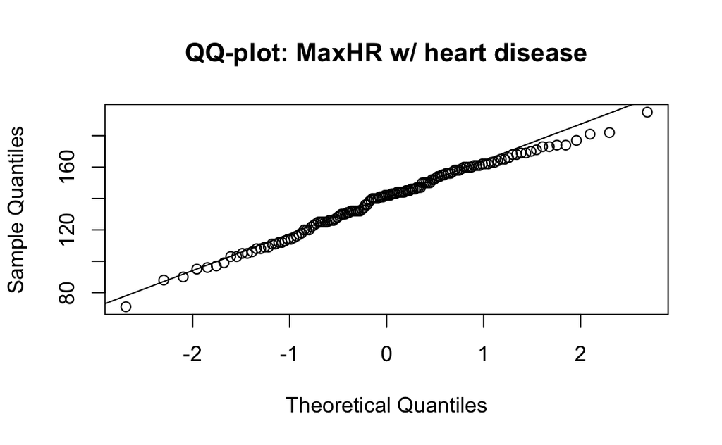

```
qqnorm(clevheart$MaxHR[clevheart$AHD == "No"], main = "QQ-plot: MaxHR w/o heart disease")
qqline(clevheart$MaxHR[clevheart$AHD == "No"])
```

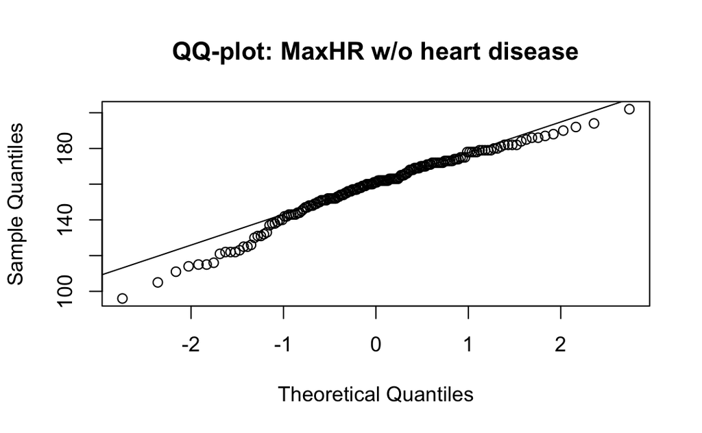

3. Do the t-test with significance level � = 0.05.

Null hypothesis The population mean MaxHR for those patients diagnosed with heart disease equals the population mean MaxHR for those patients not diagnosed with heart disease.

Alternative hypothesis The population mean MaxHR for those patients diagnosed with heart disease does not equal the population mean MaxHR for those patients not diagnosed with heart disease. Report the p-value, the 95% confidence interval for the difference of the means, and clearly state your conclusion.

```
ttest_clev <- t.test(MaxHR ~ AHD, data = clevheart)
print(ttest_clev)
```

```
    Welch Two Sample t-test

data:  MaxHR by AHD
t = 7.8579, df = 272.27, p-value = 9.106e-14
alternative hypothesis: true difference in means between group No and group Yes is not equal to 0
95 percent confidence interval:
 14.32900 23.90912
sample estimates:
 mean in group No mean in group Yes
          158.378           139.259
```

The analysis produced a p-value of 9.106e-14 and a 95% confidence interval from 14.32900 - 23.90912. Since the p-value is much smaller than 0.5, we reject the null hypothesis and conclude the mean MaxHR for patients diagnosed with heart disease doesn’t equal the population mean MaxHR for patients not diagnosed with heart disease.